# Phylogenetic Comparative Methods

```r
library(phylocompmeth)
```

## Introduction to phylogenies

Phylogenetic trees are branching diagrams illustrating the evolutionary relationships among taxa.

- Each **node** represents a speciation event in evolution.
- A **branch** connects two nodes of the tree
- **Terminal Nodes** represent the data under comparison. Also known as **Operational Taxonomic Units** *(OTUs)*

## Introduction to Phylogenetic comparative methods (PCMs)

PCMs enable us to study the history of organismal evolution and diversification. With it we can explore in depth these topics:

- Evolutionary ties between organisms
- Find and understand relationships between an ancestral sequence and its descendants
- Estimate time of divergence between a group of organisms that share a common ancestor

## `APE` package and the `phylo` class

The `ape` package (Analysis of Phylogenetics and Evolution) is used within the community of evolutionary biologists for data analysis and as a framework for the development of new analytical methods.

```r
library(ape)
```

To read and load trees into R using ape, you can use the `read.nexus` or `read.tree` functions. The `read.nexus` function reads NEXUS formatted files while the `read.tree` function reads Newick formatted trees.

```r
f <- "https://raw.githubusercontent.com/averyshepherd/phylocompmethods/main/Potential%20Nexus%20Files/T6506.nex"
tree <- read.nexus(f)
```

When the tree is read in and processed, it creates a list of class phylo. This phylo type is the basis of most PCMs.

```r
class(tree)
```

```
#> [1] "phylo"
```

```r
str(tree)
```

```
#> List of 3
#>  $ edge     : int [1:91, 1:2] 48 49 50 51 52 53 54 55 55 54 ...
#>  $ Nnode    : int 45
#>  $ tip.label: chr [1:47] "Asteranthera_ovata_05" "Sarmienta_repens" "Fieldia_australis" "Fieldia_australis_CHR" ...
#>  - attr(*, "class")= chr "phylo"
#>  - attr(*, "order")= chr "cladewise"
```

The `edge` variable in the tree contains the beginning and ending node number for the nodes and tips in the tree

```r
head(tree$edge)
```

```
#>      [,1] [,2]
#> [1,]   48   49
#> [2,]   49   50
#> [3,]   50   51
#> [4,]   51   52
#> [5,]   52   53
#> [6,]   53   54
```

The `tip.label` variable in the tree contains the labels for the tips in the tree

```r
head(tree$tip.label)
```

```
#> [1] "Asteranthera_ovata_05"            "Sarmienta_repens"
#> [3] "Fieldia_australis"                "Fieldia_australis_CHR"
#> [5] "Mitraria_coccinea"                "Negria_rhabdothamnoides_Mt_Gower"
```

`Nnode` contains the number of internal nodes in the tree

```r
head(tree$Nnode)
```

```
#> [1] 45
```

Graphical output in form of a cladogram can be obtained by calling `plot` with the tree as a parameter. This calls the `plot.phylo` function of the `ape` package.

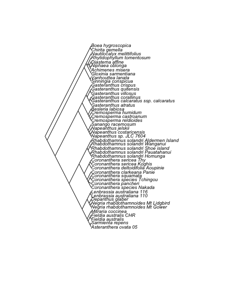

```r
plot(tree, cex = 0.6, type = "cladogram")
```

## Phytools package

The `phytools` package (Phylogenetic Tools for Comparative Biology (and Other Things)) takes advantage of functionality developed in other packages such as `ape` for many types of phylogenetic tree input and manipulation

```r
library(phytools)
```

```r
anole.resids<-cbind(anole.data[,1],
    phyl.resid(anoletree,anole.data[,1,drop=FALSE],
    anole.data[,2:ncol(anole.data)])$resid)
colnames(anole.resids)[1]<-"SVL"
```

### Heatmap

You can plot the phylogenetic heatmap using `phylo.heatmap`

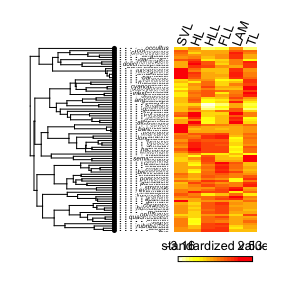

```r
phylo.heatmap(anoletree,anole.resids,
    split=c(0.7,0.3),fsize=c(0.4,0.8,0.8),
    standardize=TRUE)
```

### Principal component analysis with PCM

The `pca` function performs phylogenetic PCA

You can use the same anole data set from Mahler et al. Using `pca` from the PCM package allows you to run the phylogenetic PCA

```r
anole.pca <- pca(anoletree, anole.data)
```

`print` and `summary` allows you to see the results of the PCA (this shows you the loadings of the various PC's and proportion of variance)

```r
print(anole.pca)
```

```
#> Phylogenetic pca
#> Standard deviations:
#>        PC1        PC2        PC3        PC4        PC5        PC6
#> 0.33222579 0.09207406 0.05012082 0.04318123 0.02008655 0.01507125
#> Loads:
#>            PC1         PC2         PC3         PC4         PC5         PC6
#> SVL -0.9712234  0.16067288  0.01972570  0.14782215 -0.06211906  0.06935433
#> HL  -0.9645111  0.16955087 -0.01203113  0.17994634  0.08064324 -0.04406887
#> HLL -0.9814164 -0.02674808  0.10315533 -0.13790763  0.06887922  0.04126248
#> FLL -0.9712265  0.17585694  0.10697935 -0.09105747 -0.06075142 -0.04864769
#> LAM -0.7810052  0.37429334 -0.47398703 -0.15871456  0.00217418  0.00875408
#> TL  -0.9014509 -0.42528918 -0.07614571  0.01709649 -0.01750404 -0.01088743
```

```r
summary(anole.pca)
```

```
#> Importance of components:
#>                              PC1        PC2        PC3        PC4         PC5
#> Standard deviation     0.3322258 0.09207406 0.05012082 0.04318123 0.020086548
#> Proportion of Variance 0.8911265 0.06844587 0.02028191 0.01505437 0.003257491
#> Cumulative Proportion  0.8911265 0.95957234 0.97985426 0.99490863 0.998166120
#>                               PC6
#> Standard deviation     0.01507125
#> Proportion of Variance 0.00183388
#> Cumulative Proportion  1.00000000
```

`plot` gives you a screeplot. This shows you how much variation is explained by each component (each PC).

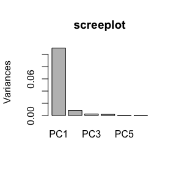

```r
plot(anole.pca)
```

To visualize the loadings, you can use `biplot`

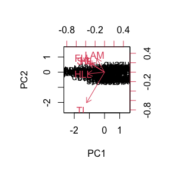

```r
biplot(anole.pca)
```

### Map visualizations

'phylo.to.map' creates an object of class "phylo.to.map" and plots that object (where tips of the tree point to coordinates on a geographic map). It is possible to map more than one geographic location per taxon.

We can simulate a phylogenetic tree to plot with `pb.tree()`.

```r
# 10 species, total length of the tree is 100
World.tree<-pbtree(n=10,scale=100)
# setting labels for branches
World.tree$tip.label<-replicate(Ntip(World.tree),
    paste(sample(LETTERS,1),".",
    paste(sample(letters,round(runif(n=1,min=3,max=10))),
    collapse=""),
    sep=""))
# simulating latitudes and longitudes
lat<-fastBM(World.tree,sig2=10,bounds=c(-90,90))
long<-fastBM(World.tree,sig2=80,bounds=c(-180,180))
# group data
World<-cbind(lat,long)
for(i in 1:Ntip(World.tree)){
    ni<-sample(0:2,1)
    for(j in 1:ni){
        World<-rbind(World,c(World[i,1]+rnorm(n=1,sd=4),
            World[i,2]+rnorm(n=1,sd=4)))
        rownames(World)[nrow(World)]<-rownames(World)[i]
    }
}
```

We can see the data we've simulated here.

```r
head(World, 20)
```

```
#>                    lat       long
#> K.zuh       -60.088610  97.298314
#> Z.bxdmtn    -39.462052 -36.649802
#> Y.nvrjfwe   -45.786160  22.243489
#> C.njwrx     -24.603936 -63.622726
#> N.dkmxaqlwj  10.374822 116.365268
#> F.tjva      -17.201697  13.863588
#> K.vxrwndmo  -37.755429 -65.262334
#> S.enc        -9.138262  -5.130596
#> L.lugfjt     -3.964152  28.705335
#> T.mbr        -6.997906  35.161491
#> K.zuh       -66.281936 102.392685
#> K.zuh       -53.174399  99.415122
#> Z.bxdmtn    -40.504769 -38.541029
#> Y.nvrjfwe   -46.936754  28.736880
#> Y.nvrjfwe   -49.204662  21.320804
#> C.njwrx     -25.438976 -63.620245
#> C.njwrx     -26.897822 -62.973265
#> N.dkmxaqlwj  10.938932 126.459692
#> F.tjva      -12.331531  16.998529
#> F.tjva      -22.976826  18.151903
```

Use `phylo.to.map()` to display the geographic locations associated with each species.

```r
obj <- phylo.to.map(World.tree, World, plot=FALSE)
```

```
#> objective: 34
#> objective: 32
#> objective: 30
#> objective: 30
#> objective: 20
#> objective: 20
#> objective: 20
#> objective: 20
#> objective: 20
```

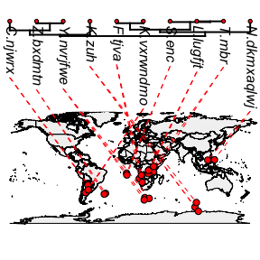

```r
# default settings
plot(obj, ftype="i")
```

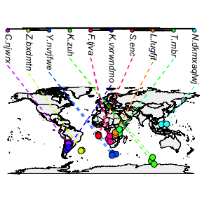

```r
# colors, font size, point size, etc. can be customized
cols<-setNames(sample(rainbow(n=Ntip(World.tree))),
    World.tree$tip.label)
plot(obj,colors=cols,ftype="i",fsize=0.8,cex.points=c(0.7,1.2))
```

### ANOVA and PCM

Next, we will look at `phyolANOVA()` which performs simulation based phylogenetic ANOVA and can conduct post-hoc comparisons of means among groups.

```r
# simulate data for the analysis
# phylogeny with 100 species
tree<-pbtree(n=100)
# transition rates
Q<-matrix(c(-2,1,1,
    1,-2,1,
    1,1,-2),3,3)
rownames(Q)<-colnames(Q)<-letters[1:3]
x<-as.factor(sim.history(tree,Q)$states)
```

```
#> Done simulation(s).
```

```r
# simulating phenotypic trait values for species for two different scenarios
y1<-fastBM(tree)
y2<-fastBM(tree,sig2=0.5)+as.numeric(x)
```

In y2, we can see that there might be some grouping in the species. There does not appear to be a pattern in y1, and we can run `phyloANOVA` to help quantify that.

[figure not shown]

```r
# y1
phenogram(tree,y1,ftype="off",col=make.transparent("blue",0.5))
tiplabels(pie=to.matrix(x,letters[1:3]),
    piecol=colorRampPalette(c("blue", "yellow"))(3),
    cex=0.4)
```

[figure not shown]

```r
# y2
phenogram(tree,y2,ftype="off",col=make.transparent("blue",0.5))
tiplabels(pie=to.matrix(x,letters[1:3]),
    piecol=colorRampPalette(c("blue", "yellow"))(3),
    cex=0.4)
```

```r
phyloANOVA(tree,x,y1)
```

```
#> ANOVA table: Phylogenetic ANOVA
#>
#> Response: y
#>              Sum Sq  Mean Sq  F value Pr(>F)
#> x          4.027216 2.013608 1.183936  0.498
#> Residual 164.975162 1.700775
#>
#> P-value based on simulation.
#> ---------
#>
#> Pairwise posthoc test using method = "holm"
#>
#> Pairwise t-values:
#>           a         b        c
#> a  0.000000 -0.188584 1.263284
#> b  0.188584  0.000000 1.358117
#> c -1.263284 -1.358117 0.000000
#>
#> Pairwise corrected P-values:
#>       a     b     c
#> a 1.000 0.996 0.996
#> b 0.996 1.000 0.996
#> c 0.996 0.996 1.000
#> ---------
```

```r
phyloANOVA(tree,x,y2)
```

```
#> ANOVA table: Phylogenetic ANOVA
#>
#> Response: y
#>             Sum Sq   Mean Sq   F value Pr(>F)
#> x         88.75181 44.375907 36.444763  0.001
#> Residual 118.10923  1.217621
#>
#> P-value based on simulation.
#> ---------
#>
#> Pairwise posthoc test using method = "holm"
#>
#> Pairwise t-values:
#>          a         b         c
#> a 0.000000 -5.858275 -8.225080
#> b 5.858275  0.000000 -1.715004
#> c 8.225080  1.715004  0.000000
#>
#> Pairwise corrected P-values:
#>       a     b     c
#> a 1.000 0.003 0.003
#> b 0.003 1.000 0.302
#> c 0.003 0.302 1.000
#> ---------
```